# Practical Machine Learning - Week 2

```r
library(caret)
library(kernlab)
library(data.table)
library(magrittr)
library(purrr)
```

## `caret` functions

- Preprocessing
- Data splitting
- Train / test / predict
- Model comparison

Gitbook: https://topepo.github.io/caret/index.html

## Algorithms

- Comes from different packages (`MASS`, `stats`, `gbm`, `mda`, …)
- `caret::predict(model_object, ...)`

## SPAM Example

```r
library(caret)
library(kernlab)
library(data.table)
library(magrittr)
data(spam)
spam %>% setDT
head(spam)
```

```
#>    make address  all num3d  our over remove internet order mail receive
#> 1: 0.00    0.64 0.64     0 0.32 0.00   0.00     0.00  0.00 0.00    0.00
#> 2: 0.21    0.28 0.50     0 0.14 0.28   0.21     0.07  0.00 0.94    0.21
#> 3: 0.06    0.00 0.71     0 1.23 0.19   0.19     0.12  0.64 0.25    0.38
#> 4: 0.00    0.00 0.00     0 0.63 0.00   0.31     0.63  0.31 0.63    0.31
#> 5: 0.00    0.00 0.00     0 0.63 0.00   0.31     0.63  0.31 0.63    0.31
#> 6: 0.00    0.00 0.00     0 1.85 0.00   0.00     1.85  0.00 0.00    0.00
#>    will people report addresses free business email  you credit your font
#> 1: 0.64   0.00   0.00      0.00 0.32     0.00  1.29 1.93   0.00 0.96    0
#> 2: 0.79   0.65   0.21      0.14 0.14     0.07  0.28 3.47   0.00 1.59    0
#> 3: 0.45   0.12   0.00      1.75 0.06     0.06  1.03 1.36   0.32 0.51    0
#> 4: 0.31   0.31   0.00      0.00 0.31     0.00  0.00 3.18   0.00 0.31    0
#> 5: 0.31   0.31   0.00      0.00 0.31     0.00  0.00 3.18   0.00 0.31    0
#> 6: 0.00   0.00   0.00      0.00 0.00     0.00  0.00 0.00   0.00 0.00    0
#>    num000 money hp hpl george num650 lab labs telnet num857 data num415
```

[output cut: 34 more lines]

```r
# Splitting
in_train <- createDataPartition(y = spam$type, times = 1, p = .75)
training <- spam[in_train$Resample1,]; dim(training)
```

```
#> [1] 3451   58
```

```r
testing <- spam[-in_train$Resample1,]; dim(testing)
```

```
#> [1] 1150   58
```

```r
# Fit a model
set.seed(32343)
model_fit <- train(type ~., data = training, method = "glm")
model_fit
```

```
#> Generalized Linear Model
#>
#> 3451 samples
#>   57 predictor
#>    2 classes: 'nonspam', 'spam'
#>
#> No pre-processing
#> Resampling: Bootstrapped (25 reps)
#> Summary of sample sizes: 3451, 3451, 3451, 3451, 3451, 3451, ...
#> Resampling results:
#>
#>   Accuracy  Kappa
#>   0.916419  0.8251215
```

```r
# str(model_fit, max.level = 1)
# model_fit$finalModel

# Prediction
pred <- predict(model_fit, newdata = testing)
head(pred)
```

```
#> [1] spam    nonspam spam    spam    spam    spam
#> Levels: nonspam spam
```

```r
# Confusion matrix
confusionMatrix(data = pred, reference = testing$type)
```

```
#> Confusion Matrix and Statistics
#>
#>           Reference
#> Prediction nonspam spam
#>    nonspam     655   46
#>    spam         42  407
#>
#>                Accuracy : 0.9235
#>                  95% CI : (0.9066, 0.9382)
#>     No Information Rate : 0.6061
#>     P-Value [Acc > NIR] : <2e-16
#>
#>                   Kappa : 0.8395
#>  Mcnemar's Test P-Value : 0.7491
#>
#>             Sensitivity : 0.9397
#>             Specificity : 0.8985
#>          Pos Pred Value : 0.9344
#>          Neg Pred Value : 0.9065
#>              Prevalence : 0.6061
#>          Detection Rate : 0.5696
#>    Detection Prevalence : 0.6096
#>       Balanced Accuracy : 0.9191
#>
#>        'Positive' Class : nonspam
#>
```

## Data Slicing

```r
# CV: K-fold
folds <- createFolds(training, k = 10, returnTrain = TRUE) # default return testing
map_int(folds, length)
```

```
#> Fold01 Fold02 Fold03 Fold04 Fold05 Fold06 Fold07 Fold08 Fold09 Fold10
#>     50     50     52     50     54     55     52     52     54     53
```

```r
folds[[1]] %>% head
```

```
#> [1] 1 2 5 6 7 8
```

# Quiz

## 1. Load the Alzheimer’s disease data using the commands:

```r
library(AppliedPredictiveModeling)
data(AlzheimerDisease)
```

Which of the following commands will create non-overlapping training and test sets with about 50% of the observations assigned to each?

```r
adData = data.frame(diagnosis,predictors)
trainIndex = createDataPartition(diagnosis, p = 0.5, list=FALSE)
training = adData[trainIndex,]
testing = adData[-trainIndex,]
```

## 2. Load the cement data using the commands:

```r
library(caret)
library(AppliedPredictiveModeling)
library(data.table)
data(concrete); setDT(concrete); setDT(mixtures)

concrete
```

```
#>       Cement BlastFurnaceSlag FlyAsh Water Superplasticizer
#>    1:  540.0              0.0    0.0 162.0              2.5
#>    2:  540.0              0.0    0.0 162.0              2.5
#>    3:  332.5            142.5    0.0 228.0              0.0
#>    4:  332.5            142.5    0.0 228.0              0.0
#>    5:  198.6            132.4    0.0 192.0              0.0
#>   ---
#> 1026:  276.4            116.0   90.3 179.6              8.9
#> 1027:  322.2              0.0  115.6 196.0             10.4
#> 1028:  148.5            139.4  108.6 192.7              6.1
#> 1029:  159.1            186.7    0.0 175.6             11.3
#> 1030:  260.9            100.5   78.3 200.6              8.6
#>       CoarseAggregate FineAggregate Age CompressiveStrength
#>    1:          1040.0         676.0  28               79.99
#>    2:          1055.0         676.0  28               61.89
#>    3:           932.0         594.0 270               40.27
#>    4:           932.0         594.0 365               41.05
#>    5:           978.4         825.5 360               44.30
#>   ---
#> 1026:           870.1         768.3  28               44.28
#> 1027:           817.9         813.4  28               31.18
#> 1028:           892.4         780.0  28               23.70
#> 1029:           989.6         788.9  28               32.77
#> 1030:           864.5         761.5  28               32.40
```

```r
mixtures
```

```
#>           Cement BlastFurnaceSlag     FlyAsh      Water Superplasticizer
#>    1: 0.22309440       0.00000000 0.00000000 0.06692832      0.001032844
#>    2: 0.22172039       0.00000000 0.00000000 0.06651612      0.001026483
#>    3: 0.14917003       0.06393001 0.00000000 0.10228802      0.000000000
#>    4: 0.14917003       0.06393001 0.00000000 0.10228802      0.000000000
#>    5: 0.08534961       0.05689974 0.00000000 0.08251322      0.000000000
#>   ---
#> 1026: 0.11967440       0.05022515 0.03909768 0.07776238      0.003853481
#> 1027: 0.14159525       0.00000000 0.05080202 0.08613492      0.004570424
#> 1028: 0.06548485       0.06147198 0.04788993 0.08497597      0.002689950
#> 1029: 0.06883870       0.08078055 0.00000000 0.07597785      0.004889235
#> 1030: 0.11468636       0.04417777 0.03441910 0.08817970      0.003780386
#>       CoarseAggregate FineAggregate Age CompressiveStrength
#>    1:       0.4296633     0.2792811  28               79.99
#>    2:       0.4331759     0.2775611  28               61.89
#>    3:       0.4181247     0.2664872 270               40.27
#>    4:       0.4181247     0.2664872 365               41.05
#>    5:       0.4204736     0.3547638 360               44.30
#>   ---
#> 1026:       0.3767319     0.3326550  28               44.28
#> 1027:       0.3594375     0.3574599  28               31.18
#> 1028:       0.3935265     0.3439608  28               23.70
#> 1029:       0.4281758     0.3413378  28               32.77
#> 1030:       0.3800167     0.3347400  28               32.40
```

```r
set.seed(1000)
inTrain <- createDataPartition(mixtures$CompressiveStrength, p = 3/4)[[1]]
training <- mixtures[ inTrain,]
testing <- mixtures[-inTrain,]
```

Make a plot of the outcome (CompressiveStrength) versus the index of the samples. Color by each of the variables in the data set (you may find the `cut2()` function in the Hmisc package useful for turning continuous covariates into factors). What do you notice in these plots?

1. There is a non-random pattern in the plot of the outcome versus index.
2. There is a non-random pattern in the plot of the outcome versus index that is perfectly explained by the Age variable so there may be a variable missing.
3. There is a non-random pattern in the plot of the outcome versus index that does not appear to be perfectly explained by any predictor suggesting a variable may be missing.
4. There is a non-random pattern in the plot of the outcome versus index that is perfectly explained by the FlyAsh variable so there may be a variable missing.

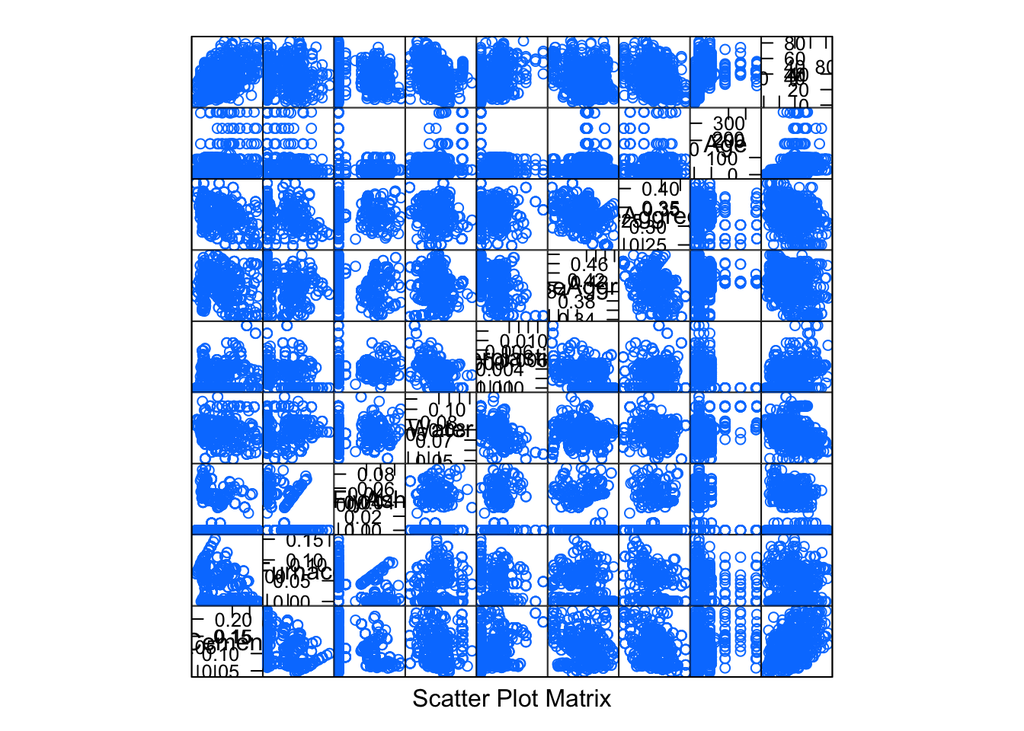

```r
caret::featurePlot(x = training[, 1:8],
                   y = training$CompressiveStrength,
                   plot="pairs")
```

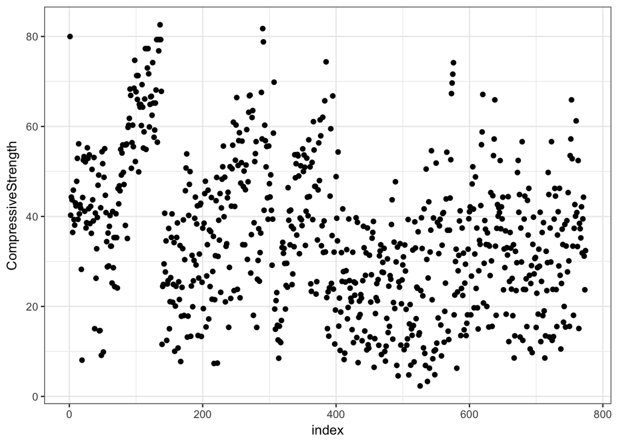

```r
# No relation between the outcome and other variables

index <- 1:nrow(training)
ggplot(training, aes(x=index, y=CompressiveStrength)) +
  geom_point() +
  theme_bw()
```

```r
# Step-like pattern -> 4 categories

library(Hmisc)
cutCompressiveStrength <- Hmisc::cut2(training$CompressiveStrength, g=4)
summary(cutCompressiveStrength)
```

```
#> [ 2.33,23.7) [23.74,34.6) [34.56,46.2) [46.23,82.6]
#>          194          193          194          193
```

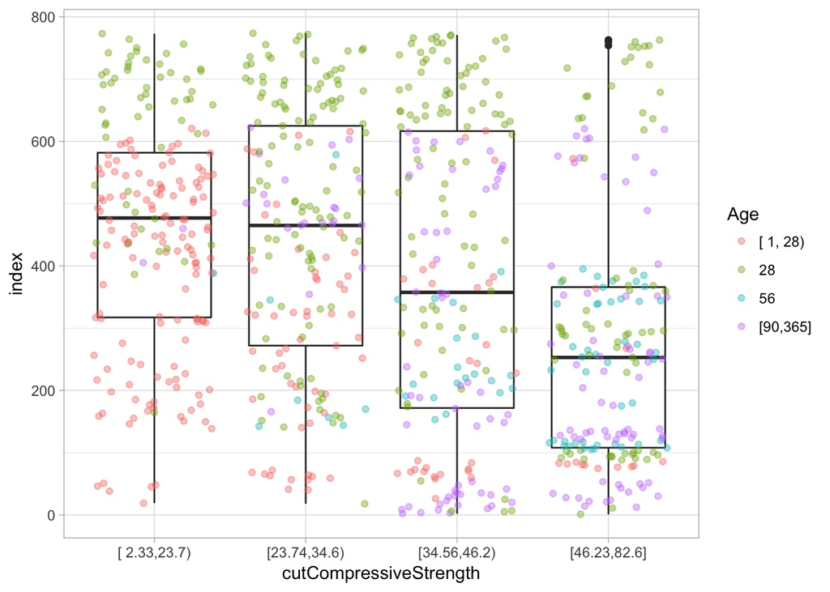

```r
ggplot(data=training, aes(y=index, x=cutCompressiveStrength)) +
  geom_boxplot() +
  geom_jitter(aes(colour = cut2(training$Age, g=4)), alpha = 0.4) +
  guides(color = guide_legend("Age")) +
  theme_light()
```

```r
# There is a step-like pattern in the plot of outcome versus index
# in the training set that isn't explained by any of the predictor
# variables so there may be a variable missing.
```

## 3. Load the cement data using the commands:

```r
library(caret)
library(AppliedPredictiveModeling)
data(concrete)

set.seed(1000)
inTrain <- createDataPartition(mixtures$CompressiveStrength, p = 3/4)[[1]]
training <- mixtures[ inTrain,]
testing <- mixtures[-inTrain,]
```

Make a histogram and confirm the SuperPlasticizer variable is skewed. Normally you might use the log transform to try to make the data more symmetric. Why would that be a poor choice for this variable?

1. The SuperPlasticizer data include negative values so the log transform can not be performed.
2. There are a large number of values that are the same and even if you took the log(SuperPlasticizer + 1) they would still all be identical so the distribution would not be symmetric.
3. The log transform does not reduce the skewness of the non-zero values of SuperPlasticizer
4. The log transform is not a monotone transformation of the data.

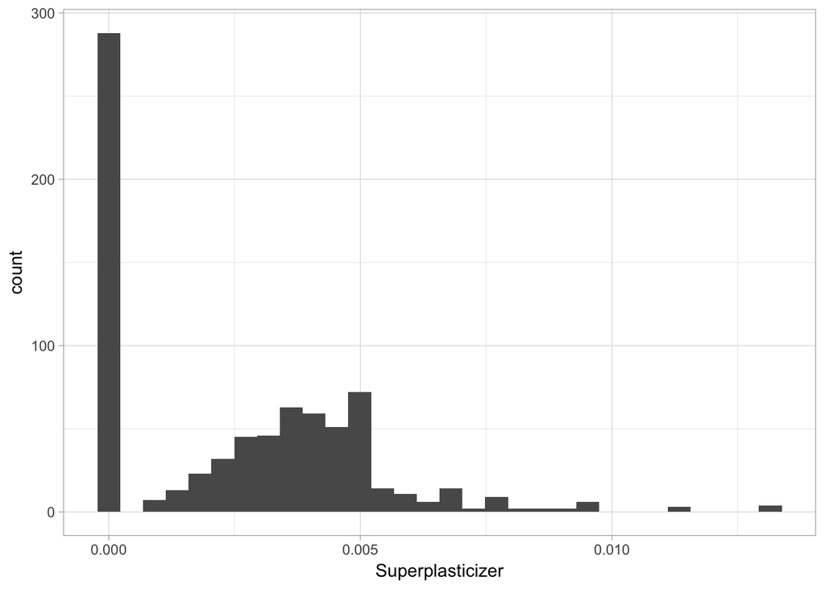

```r
ggplot(data=training, aes(x=Superplasticizer)) +
  geom_histogram(bin = 30) +
  theme_light()
```

There are a large number of values that are the same and even if you took the log(SuperPlasticizer + 1) they would still all be identical so the distribution would not be symmetric. There are values of zero so when you take the log() transform those values will be -Inf.